Skip to main content

# Which Shelter Animals Wait Longest?

A survival analysis of 11+ years of Austin Animal Center data (2013–2025)

Author

Kristina Diaz-Kerkado

Published

November 20, 2026

163,653 Dog & cat stays analyzed (2013–2025)

13x – 17x Early mortality rate for injured/sick intakes

0.83 AUC Out-of-time 14-day risk model accuracy

## Executive Summary

**Research Question.** Which animal characteristics and intake conditions drive length of stay and shelter outcomes at the Austin Animal Center? Can high-risk animals be flagged at intake—using only information known at the door—early enough for staff to intervene?

**Data Scope.** 163,653 cleaned dog and cat stays (94,397 dogs and 69,256 cats) from October 2013 to May 2025 via the City of Austin Open Data Portal, plus 19,547 newer-schema intakes (May 2025–November 2026) used for cross-schema validation.

**Key Findings.**

- **Species exit through different pathways:** Roughly half of both species are adopted (50% of dogs, 51% of cats), but **25% of dogs are reclaimed by an owner** (versus 4% of cats), while **38% of cats are transferred** to rescue partners (versus 22% of dogs).
- **Dogs are adopted faster initially, but cats catch up:** Within 7 days, 22% of dog stays end in adoption compared to 13% of cat stays. By day 90, cumulative adoption shares converge at 46% to 47%.
- **Arrival condition is the strongest signal of mortality:** In the first two weeks, injured and sick animals die or are euthanized at **13 to 17 times the rate** of animals arriving in normal condition. Nearly **29% of injured cats** and **22% of sick cats** die or are euthanized, compared to 12% and 11% of dogs, and under 3% of animals arriving in normal condition.
- **Age reshapes exit pathways:** Animals aged 8 weeks to 1 year are adopted fastest. Among dogs over 5 years old, lower adoption shares (24.4%) reflect high owner-reclaim rates (46.1%) as much as longer waits. Most neonatal and nursing animals exit via partner transfers (68.9% of cats, 53.0% of dogs).
- **Factor effects shift over the course of a stay:** Time-varying Cox models show that injured and neonatal animals are adopted far more slowly during their first two weeks, but among those still waiting past week eight, the gap narrows or reverses (puppies under 8 weeks at intake are adopted nearly **3x faster** once they reach adoptable age).
- **Intake risk scoring vs. simple triage rules:** A logistic regression model trained on pre-2022 intakes achieves an **AUC of 0.83** on unseen 2022–2025 arrivals when predicting death or euthanasia within 14 days. At the same alert volume (~14% of intakes), the model catches **66.1%** of poor outcomes compared to **64.4%** caught by a simple rule flagging every injured or sick animal.

**Future Work.** Incorporate breed and size text features and explore multi-state competing-risks models to estimate expected kennel-days saved per early foster intervention.

## Why This Matters

Animal shelters operate with finite kennel space, staff time, and medical budgets. Every extra day an animal remains in care increases operational costs and heightens behavioral and health risks. If a shelter can identify at intake which animals are most likely to wait longest or experience a poor outcome, it can prioritize foster placement, medical triage, behavior support, and targeted adoption marketing from day one.

## The Data

Austin Animal Center publishes two datasets on the City of Austin Open Data Portal: **intakes** (animals arriving) and **outcomes** (animals leaving). Each exists in two formats. In May 2025 the published schema changed—introducing new column names and a new animal ID format—so the two periods cannot simply be stacked together.

The primary analysis covers **October 2013 to May 2025**, while the newer **May 2025 to November 2026** files are mapped separately to test out-of-schema generalization.

| Dataset | Period | Rows |
| --- | --- | --- |
| Intakes (legacy format) | Oct 2013 – May 2025 | 173,812 |
| Outcomes (legacy format) | Oct 2013 – May 2025 | 173,775 |
| Intakes (new schema) | May 2025 – Nov 2026 | 19,547 |
| Outcomes (new schema) | May 2025 – Nov 2026 | 19,903 |

## Preparing the Data

Each row in the intake file represents one arrival. To measure length of stay, I matched each arrival to that animal’s **next** departure in the outcomes file and calculated the elapsed days. All data-cleaning steps are reproducible via the expandable code blocks below.

### Dates and Outcomes

The source files store timestamps in mixed formats, so I standardized them to calendar dates and lowercased outcome labels so variations like `"Adoption"` and `"adoption"` are treated identically.

**Show R code: date parsing and outcome standardization**

```r
# Helper: parse dates stored as text, dates, or date-times into plain Date objects
to_date <- function(x) {
  if (inherits(x, c("Date", "POSIXt"))) {
    as_date(x)
  } else {
    as_date(parse_date_time(x, orders = c("YbdIMSp",
                                          "YmdHMS",
                                          "Ymd",
                                          "mdYIMSp")))
  }
}

intakes_old <- intakes_old |>
  mutate(intake_id = row_number(),
         intake_date = to_date(date_time))

outcomes_old_clean <- outcomes_old |>
  transmute(animal_id,
            outcome_date = to_date(date_time),
            outcome_type)

# Lowercase outcome labels so "Adoption" and "adoption" count as the same thing
outcomes_all <- outcomes_old_clean |>
  mutate(outcome_type = str_to_lower(outcome_type)) |>
  distinct()
```

### Reconstructing Individual Stays

**Show R code: chronological intake-to-outcome matching**

```r
# Step 1: pair each intake with its chronologically next outcome
matched <- intakes_old |>
  select(intake_id, animal_id, intake_date) |>
  inner_join(outcomes_all, by = "animal_id", relationship = "many-to-many") |>
  filter(outcome_date >= intake_date) |>   # keep outcomes on or after arrival
  group_by(intake_id) |>
  slice_min(outcome_date, n = 1, with_ties = FALSE) |>   # earliest one ends the stay
  ungroup() |>
  select(intake_id, outcome_date, outcome_type)

# Step 2: join matched outcomes back onto every intake
data_cutoff <- as_date("2025-05-05")   # end date of legacy files

stays <- intakes_old |>
  left_join(matched, by = "intake_id") |>
  mutate(still_in_shelter = is.na(outcome_date),
         end_date = coalesce(outcome_date, data_cutoff),
         los_days = as.numeric(end_date - intake_date))
```

### Filtering to Companion Animals & Grouping Outcomes

**Show R code: cohort filtering and outcome grouping**

```r
stays_clean <- stays |>
  filter(animal_type %in% c("Dog", "Cat")) |>
  filter(!intake_type %in% c("Euthanasia Request", "Wildlife")) |>
  filter(!(still_in_shelter & los_days > 365)) |>
  mutate(outcome_group = case_when(
    still_in_shelter                                    ~ "Still in shelter",
    is.na(outcome_type)                                 ~ "Unknown outcome",
    outcome_type == "adoption"                          ~ "Adopted",
    outcome_type %in% c("return to owner", "rto-adopt") ~ "Returned to owner",
    outcome_type == "transfer"                          ~ "Transferred",
    outcome_type %in% c("euthanasia", "died")           ~ "Died or euthanized",
    TRUE                                                ~ "Other outcome"
  ))
```

### Engineering Intake-Only Features

To ensure the models reflect real-world triage at the shelter door, predictors are restricted strictly to attributes recorded upon arrival.

**Show R code: intake-only feature engineering**

```r
stays_clean <- stays_clean |>
  mutate(
    # Age: convert text like "2 years" or "3 weeks" into numeric days
    age_number = parse_number(age_upon_intake),
    age_days = case_when(
      str_detect(age_upon_intake, "year")  ~ age_number * 365,
      str_detect(age_upon_intake, "month") ~ age_number * 30,
      str_detect(age_upon_intake, "week")  ~ age_number * 7,
      str_detect(age_upon_intake, "day")   ~ age_number,
      TRUE                                 ~ NA_real_
    ),
    age_days = if_else(age_days < 0, NA_real_, age_days),

    # Sex and spay/neuter status parsed from combined intake column
    sex = case_when(
      str_detect(sex_upon_intake, "Female") ~ "female",
      str_detect(sex_upon_intake, "Male")   ~ "male",
      TRUE                                  ~ "unknown"
    ),
    fixed = case_when(
      str_detect(sex_upon_intake, "Neutered|Spayed") ~ "fixed",
      str_detect(sex_upon_intake, "Intact")          ~ "intact",
      TRUE                                           ~ "unknown"
    ),

    # Indicator for arriving with an existing name (* denotes shelter-assigned names)
    has_own_name = !is.na(name) & !str_detect(name, fixed("*")),

    # Temporal features
    intake_year  = year(intake_date),
    intake_month = month(intake_date, label = TRUE),

    # Consolidate 20 raw intake conditions into clinically meaningful categories
    condition_group = case_when(
      intake_condition == "Normal"  ~ "Normal",
      intake_condition == "Injured" ~ "Injured",
      intake_condition %in% c("Sick", "Medical", "Med Attn", "Med Urgent",
                              "Neurologic", "Parvo", "Panleuk", "Congenital",
                              "Agonal")           ~ "Sick or medical",
      intake_condition %in% c("Neonatal", "Nursing") ~ "Neonatal or nursing",
      intake_condition %in% c("Behavior", "Feral")   ~ "Behavior or feral",
      intake_condition == "Aged"     ~ "Aged",
      intake_condition == "Pregnant" ~ "Pregnant",
      TRUE                           ~ "Other or unknown"
    ),
    condition_group = factor(condition_group,
                             levels = c("Normal", "Injured", "Sick or medical",
                                        "Neonatal or nursing", "Aged", "Pregnant",
                                        "Behavior or feral", "Other or unknown")),

    # Life-stage brackets
    age_group = cut(age_days,
                    breaks = c(-Inf, 56, 365, 365 * 5, Inf),
                    labels = c("Under 8 weeks", "8 weeks to 1 year",
                               "1 to 5 years", "Over 5 years"))
  )
```

### Methodological Decisions

| Analytical Decision | Rationale |
| --- | --- |
| **Dogs and cats only** | Wildlife, birds, and livestock follow fundamentally different regulatory and care pathways. |
| **Chronological intake-to-outcome matching** | Animals frequently enter the shelter multiple times; each stay must be paired with its subsequent exit. |
| **Right-censoring open stays as of 5 May 2025** | Unmatched arrivals within one year of cutoff are retained as `"Still in shelter"` so their minimum wait time informs survival estimates. |
| **Excluding unmatched stays > 365 days** | Open records exceeding one year almost certainly reflect missing discharge logs rather than active kennel stays. |
| **Removing owner-requested euthanasia & wildlife** | These intakes were never eligible for general adoption or shelter housing. |
| **Grouping `died` and `euthanasia`** | Both represent non-live outcomes; 68% of euthanasia was due to suffering, and ~75% of deaths occurred in shelter or foster care. |
| **Grouping `rto-adopt` with `return to owner`** | Represents an owner reclaiming their pet through a formal adoption workflow. |
| **Intake-only predictor set** | Prevents data leakage and ensures any risk-scoring tool works at the moment of arrival. |
| **Species-specific models with clustered `animal_id`** | Dogs and cats exhibit distinct exit dynamics, and clustering accounts for repeat visits by the same animal. |

After applying these criteria, the final analytical cohort covers **163,653 stays**: **94,397 dogs** and **69,256 cats**, including **911 right-censored stays** still in care at the cutoff date.

## Exploring the Data

### How Stays End

Dogs and cats exit the shelter through very different channels, which directly impacts how “time to adoption” should be modeled. An animal reclaimed by its owner or transferred to a rescue partner exits the adoption pool altogether.

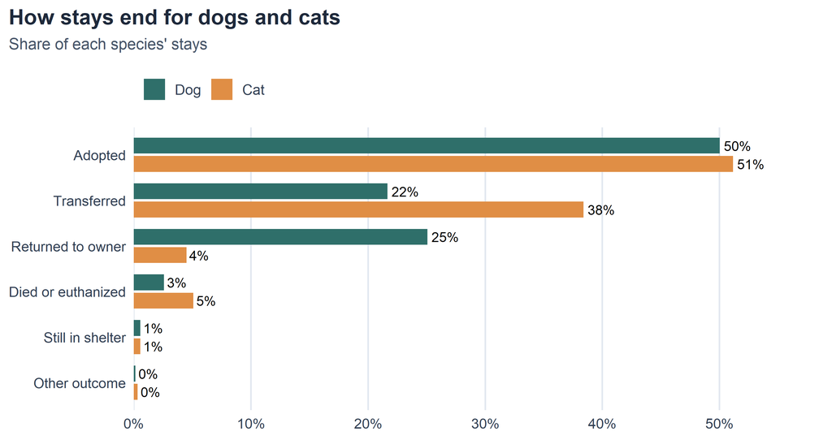

Source: Austin Animal Center, Oct 2013 to May 2025.

Roughly half of both species are adopted. However, dogs are six times as likely to be reclaimed by an owner (25% vs. 4%), often within days of arrival, whereas cats are much more likely to be transferred to partner organizations (38% vs. 22%).

### Intakes Over Time

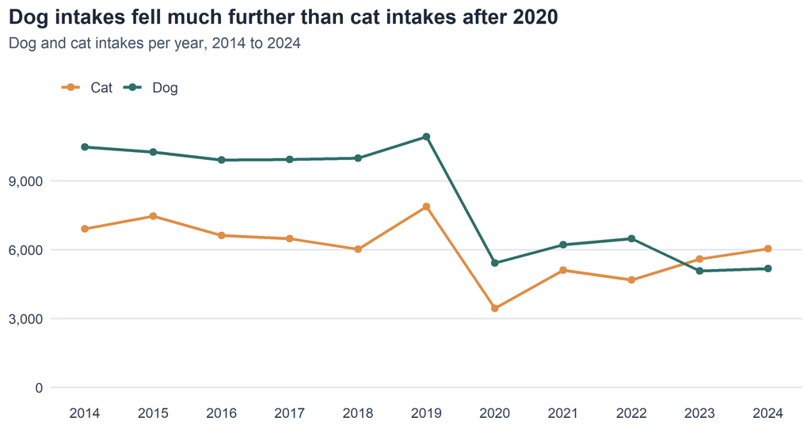

2013 and 2025 are excluded because the legacy files cover only part of those years. Source: Austin Animal Center.

Intakes for both species dropped by roughly half in 2020 during the COVID-19 pandemic. By 2024, cat intakes had rebounded to within 12% of their 2014–2019 average, while dog intakes remained at roughly half of pre-pandemic volume. Since 2023, the shelter has taken in more cats than dogs annually—a structural shift accounted for in the regression models via a pre/post-2020 indicator.

### Condition on Arrival

While 86% of animals arrive in normal health, a substantial minority arrive injured, sick, or neonatal.

| Condition on arrival | Stays | Share of all stays |
| --- | --- | --- |
| Normal | 140,695 | 86.0% |
| Injured | 9,315 | 5.7% |
| Sick or medical | 6,681 | 4.1% |
| Neonatal or nursing | 5,715 | 3.5% |
| Aged | 481 | 0.3% |
| Pregnant | 170 | 0.1% |
| Behavior or feral | 225 | 0.1% |
| Other or unknown | 371 | 0.2% |

### Who Is Most at Risk?

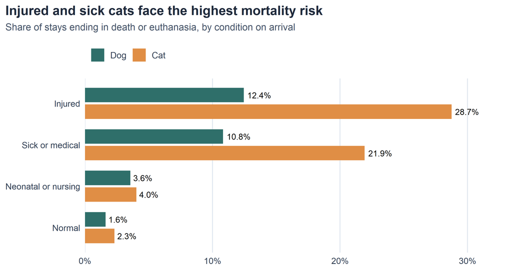

Conditions with fewer than 1,000 stays for a species are omitted here (see Appendix for full breakdown). Source: Austin Animal Center.

Injured and sick animals face dramatically higher mortality than healthy arrivals, with the sharpest disparity among cats: **28.7% of injured cats** and **21.9% of sick cats** died or were euthanized, compared with **12.4%** and **10.8%** of dogs. Animals arriving in normal condition rarely experience non-live outcomes (2.3% of cats, 1.6% of dogs).

## Survival Analysis

### Cumulative Incidence: How Long Until Each Outcome?

Because an animal can exit via adoption, owner reclaim, transfer, or death/euthanasia, these outcomes act as **competing risks**. The cumulative incidence curves below show, for each day since arrival, the proportion of all intakes that have already exited via a specific pathway, treating stays still open on May 5, 2025 as right-censored.

**Show R code: competing-risks cumulative incidence estimation**

```r
stays_cr <- stays_clean |>
  filter(outcome_group != "Unknown outcome") |>
  mutate(event = if_else(outcome_group == "Still in shelter",
                         "Censored", outcome_group),
         event = factor(event, levels = c("Censored", "Adopted",
                                          "Returned to owner", "Transferred",
                                          "Died or euthanized", "Other outcome")))

cm_species <- cuminc(Surv(los_days, event) ~ animal_type, data = stays_cr)
```

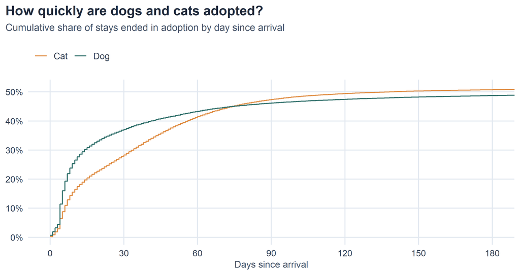

Stays still open when the data ended are treated as censored. Source: Austin Animal Center.

Dogs are adopted faster initially: within 7 days, **21.9%** of dog stays end in adoption compared to **12.9%** of cat stays, and by day 30 the shares reach **37.1%** and **28.3%**. Thereafter, the dog curve flattens while cat adoptions continue climbing, crossing at roughly day 75. By day 90, **47.4%** of cat stays and **46.2%** of dog stays have ended in adoption.

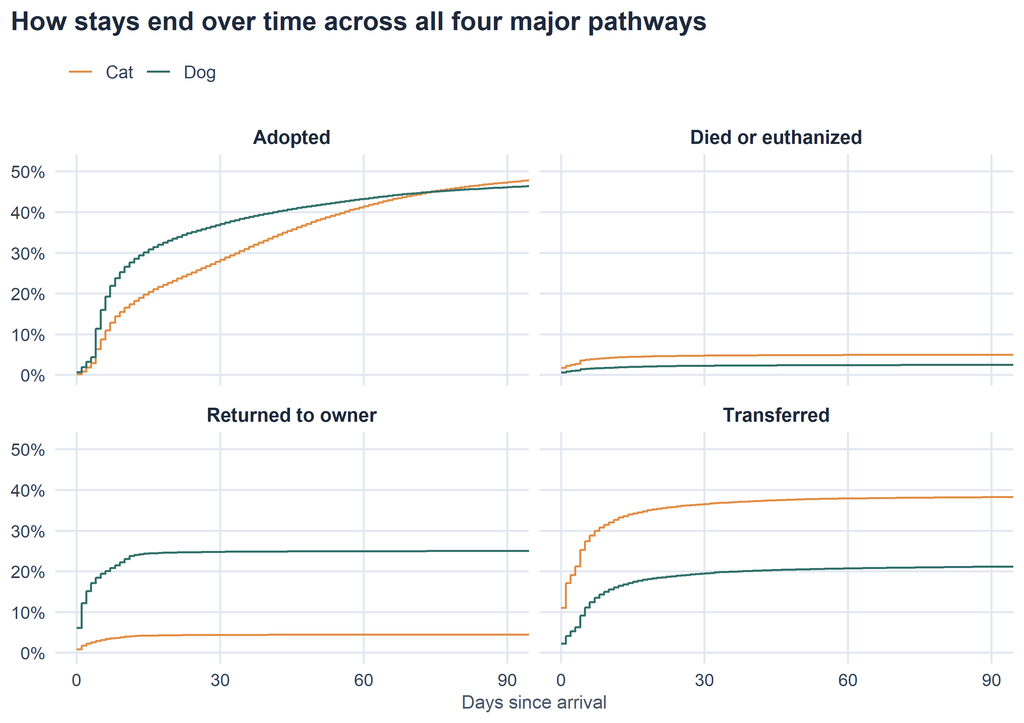

Cumulative share of stays ended in each outcome, by day since arrival. Source: Austin Animal Center.

Non-adoption outcomes diverge even more sharply by species and occur mostly within the first week. **20.8%** of dog stays end in owner reclaim within 7 days (vs. **3.5%** of cats), while **30.0%** of cat stays end in rescue transfer within 7 days (vs. **13.5%** of dogs). Deaths and euthanasia are concentrated early: **4.0%** of cat stays and **1.7%** of dog stays within the first week, rising only modestly by day 90.

| Outcome | Species | By day 7 | By day 30 | By day 60 | By day 90 |
| --- | --- | --- | --- | --- | --- |
| Adopted | Cat | 12.9% | 28.3% | 41.5% | 47.4% |
| Adopted | Dog | 21.9% | 37.1% | 43.3% | 46.2% |
| Died or euthanized | Cat | 4.0% | 4.8% | 4.9% | 5.0% |
| Died or euthanized | Dog | 1.7% | 2.3% | 2.4% | 2.5% |
| Returned to owner | Cat | 3.5% | 4.4% | 4.5% | 4.5% |
| Returned to owner | Dog | 20.8% | 24.8% | 25.0% | 25.0% |
| Transferred | Cat | 30.0% | 36.6% | 37.9% | 38.2% |
| Transferred | Dog | 13.5% | 19.6% | 20.8% | 21.2% |

### Does Age at Arrival Matter?

**Show R code: cumulative incidence by species and age group**

```r
cm_age <- cuminc(
  Surv(los_days, event) ~ species_age,
  data = stays_cr |>
    filter(!is.na(age_group)) |>
    mutate(species_age = paste(animal_type, age_group, sep = " | "))
)
```

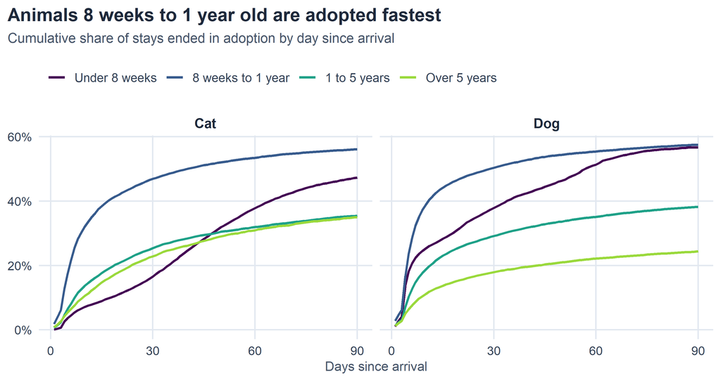

Stays still open when the data ended are treated as censored. Source: Austin Animal Center.

| Species | Age at arrival | By day 7 | By day 30 | By day 90 |
| --- | --- | --- | --- | --- |
| Cat | Under 8 weeks | 5.4% | 16.6% | 47.3% |
| Cat | 8 weeks to 1 year | 25.5% | 46.9% | 56.1% |
| Cat | 1 to 5 years | 10.0% | 25.3% | 35.4% |
| Cat | Over 5 years | 7.6% | 22.8% | 35.0% |
| Dog | Under 8 weeks | 22.4% | 37.9% | 56.7% |
| Dog | 8 weeks to 1 year | 32.4% | 50.3% | 57.5% |
| Dog | 1 to 5 years | 14.8% | 29.2% | 38.2% |
| Dog | Over 5 years | 8.7% | 17.9% | 24.4% |

Age at arrival strongly shapes both speed and destination, though patterns differ by species:

- **Juveniles (8 weeks to 1 year):** Adopted fastest and most often in both species—**56.1%** of cats and **57.5%** of dogs within 90 days (**25.5%** and **32.4%** within week one).
- **Older dogs:** Adoption share falls from **57.5%** (8 weeks–1 year) to **38.2%** (1–5 years) and **24.4%** (over 5 years), largely because owner reclaims climb from **17.3%** to **32.4%** to **46.1%**. Nearly half of senior dogs go home with their original owners.
- **Older cats:** Adult cats (1–5 years and over 5 years) share similar 90-day adoption shares (~35%), but senior cats over 5 face the highest mortality risk (**11.9%** vs. 3.3%–7.0% for younger brackets).
- **Neonates (< 8 weeks):** Puppies under 8 weeks are adopted briskly (**22.4%** within a week, **56.7%** by day 90). Kittens under 8 weeks start slowly (**5.4%** in week one) and reach **47.3%** by day 90, with **42.5%** transferred to partner organizations.

*Note: Row shares below reflect cumulative incidence across all arrivals at day 90 and do not sum to 100% because some stays ended in other outcomes or remained open.*

| Species | Age at arrival | Adopted | Returned to owner | Transferred | Died or euthanized |
| --- | --- | --- | --- | --- | --- |
| Cat | Under 8 weeks | 47.3% | 0.3% | 42.5% | 4.5% |
| Cat | 8 weeks to 1 year | 56.1% | 3.8% | 33.6% | 3.3% |
| Cat | 1 to 5 years | 35.4% | 11.8% | 40.3% | 7.0% |
| Cat | Over 5 years | 35.0% | 17.5% | 26.8% | 11.9% |
| Dog | Under 8 weeks | 56.7% | 3.7% | 35.4% | 2.6% |
| Dog | 8 weeks to 1 year | 57.5% | 17.3% | 20.3% | 1.3% |
| Dog | 1 to 5 years | 38.2% | 32.4% | 19.0% | 3.0% |
| Dog | Over 5 years | 24.4% | 46.1% | 17.7% | 4.6% |

### Does Condition on Arrival Matter?

**Show R code: cumulative incidence by species and intake condition**

```r
cm_cond <- cuminc(
  Surv(los_days, event) ~ species_cond,
  data = stays_cr |>
    filter(condition_group %in% c("Normal", "Injured", "Sick or medical",
                                  "Neonatal or nursing")) |>
    mutate(species_cond = paste(animal_type, condition_group, sep = " | "))
)
```

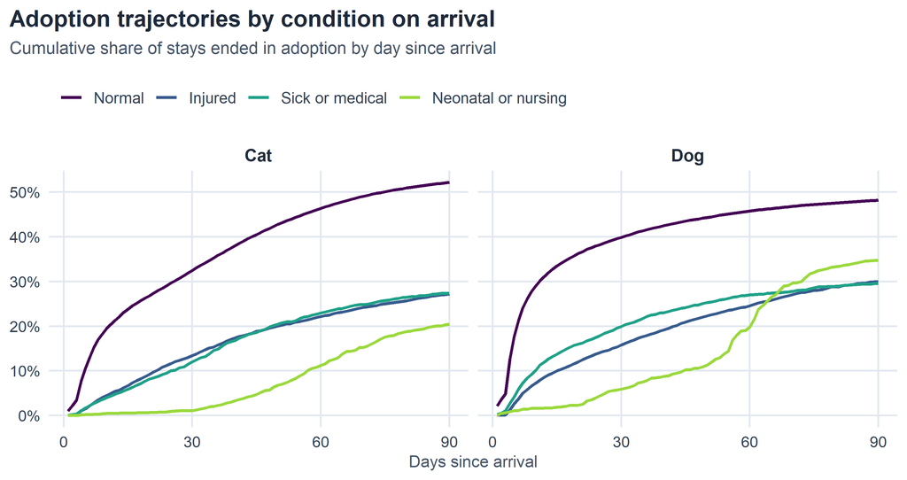

Stays still open when the data ended are treated as censored. Source: Austin Animal Center.

| Species | Condition on arrival | Adopted | Returned to owner | Transferred | Died or euthanized |
| --- | --- | --- | --- | --- | --- |
| Cat | Normal | 52.2% | 4.5% | 36.6% | 2.2% |
| Cat | Injured | 27.2% | 6.8% | 29.2% | 28.6% |
| Cat | Sick or medical | 27.4% | 6.2% | 38.9% | 21.6% |
| Cat | Neonatal or nursing | 20.5% | 0.4% | 68.9% | 4.1% |
| Dog | Normal | 48.2% | 26.3% | 19.1% | 1.5% |
| Dog | Injured | 30.0% | 18.9% | 28.4% | 12.4% |
| Dog | Sick or medical | 29.6% | 8.2% | 45.8% | 10.8% |
| Dog | Neonatal or nursing | 34.6% | 6.2% | 53.0% | 3.6% |

Animals arriving in normal condition are adopted most frequently (**52.2%** of cats and **48.2%** of dogs within 90 days). Among injured or sick arrivals, 90-day adoption drops to roughly **27%** for cats and **30%** for dogs, while non-live outcomes claim **28.6%** of injured cats and **21.6%** of sick cats (vs. **12.4%** and **10.8%** of dogs).

Neonatal and nursing animals exit primarily via rescue transfers (**68.9%** of cats and **53.0%** of dogs). Almost no neonatal cats are adopted in month one (~1%). Neonatal dogs are adopted slowly until roughly day 55–60, when their adoption curve inflects sharply upward—aligning with puppies reaching standard 8-week adoption eligibility.

### Multivariable Modeling: Which Factors Matter Most?

Intake variables overlap—kittens frequently arrive neonatal, older pets arrive sick, and strays can be reclaimed whereas owner surrenders generally cannot. To isolate each factor’s independent effect, I fit **cause-specific Cox proportional hazards models** separately for dogs and cats.

In a cause-specific model, an animal exiting via a competing pathway (such as owner reclaim or transfer) is treated as right-censored for adoption at its exit time, estimating the instantaneous adoption rate among animals *still waiting in the shelter*. Repeat visits by the same animal are clustered (`cluster(animal_id)`) to produce robust standard errors.

**Show R code: cause-specific Cox proportional hazards models**

```r
stays_model <- stays_clean |>
  filter(outcome_group != "Unknown outcome", !is.na(age_group)) |>
  mutate(
    condition_model = case_when(
      condition_group %in% c("Normal", "Injured", "Sick or medical",
                             "Neonatal or nursing") ~ as.character(condition_group),
      TRUE ~ "Other"),
    condition_model = factor(condition_model,
                             levels = c("Normal", "Injured", "Sick or medical",
                                        "Neonatal or nursing", "Other")),
    age_group   = relevel(age_group, ref = "8 weeks to 1 year"),
    sex_fixed   = relevel(factor(paste(sex, fixed)), ref = "female intact"),
    intake_type = factor(intake_type,
                         levels = c("Stray", "Owner Surrender",
                                    "Public Assist", "Abandoned")),
    era = if_else(intake_year <= 2019, "2013 to 2019", "2020 to 2025")
  )

dogs <- stays_model |> filter(animal_type == "Dog")
cats <- stays_model |> filter(animal_type == "Cat")

# cluster(animal_id) accounts for repeat visits by the same animal
fit_adopt_dog <- coxph(Surv(los_days, outcome_group == "Adopted") ~
                         age_group + condition_model + sex_fixed +
                         intake_type + has_own_name + era + cluster(animal_id),
                       data = dogs)
fit_adopt_cat <- coxph(Surv(los_days, outcome_group == "Adopted") ~
                         age_group + condition_model + sex_fixed +
                         intake_type + has_own_name + era + cluster(animal_id),
                       data = cats)
fit_death_dog <- coxph(Surv(los_days, outcome_group == "Died or euthanized") ~
                         age_group + condition_model + sex_fixed +
                         intake_type + has_own_name + era + cluster(animal_id),
                       data = dogs)
fit_death_cat <- coxph(Surv(los_days, outcome_group == "Died or euthanized") ~
                         age_group + condition_model + sex_fixed +
                         intake_type + has_own_name + era + cluster(animal_id),
                       data = cats)
```

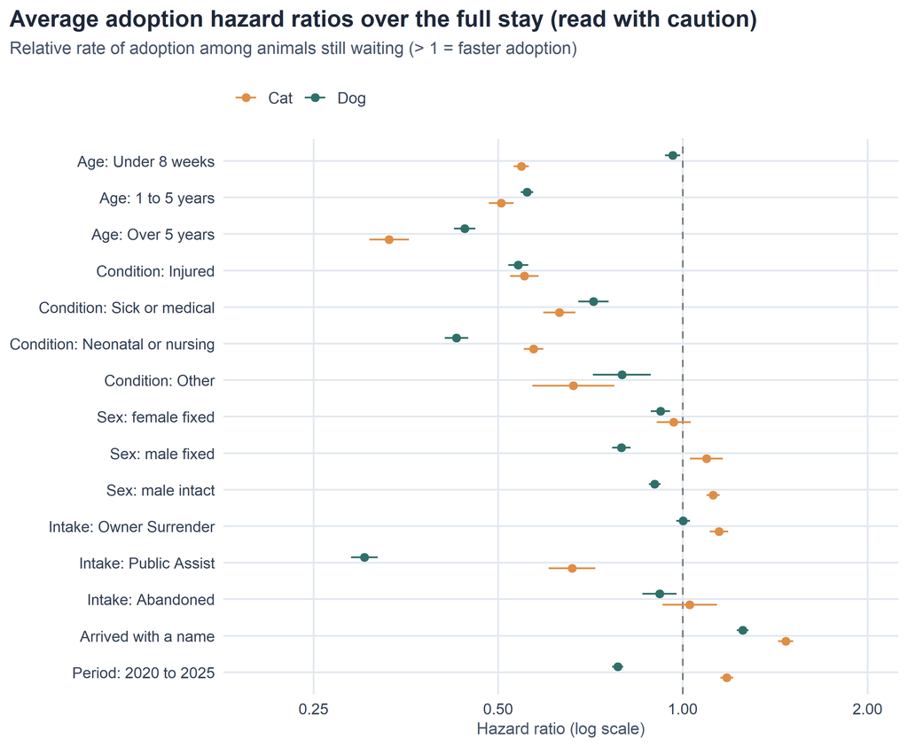

Hazard ratios with 95% confidence intervals. Dashed line at 1.0 = reference group (8 weeks–1 year, Normal condition, intact female, Stray, unnamed, 2013–2019). Animals with unrecorded sex (~3.5% of stays) are omitted from adoption plots because almost none were adopted. Source: Austin Animal Center.

### Time-Varying Effects: How Drivers Shift Over a Stay

Schoenfeld residual diagnostics (see Appendix) show that nearly every covariate violates the proportional hazards assumption—meaning its effect changes substantially as a stay progresses. Averaging across the whole stay masks critical dynamics. Below, the models are stratified into three distinct phases: **Days 0–14**, **Days 15–56**, and **Day 57 onward**.

**Show R code: piecewise time-varying Cox models for adoption**

```r
# Three phases of a shelter stay (in days since arrival)
windows <- tibble(window = c("Days 0 to 14", "Days 15 to 56", "Day 57 onward"),
                  from   = c(0, 14, 56),
                  to     = c(14, 56, Inf))

# Fit cause-specific Cox model within a single risk window
fit_window <- function(data, event_label, from, to) {
  data |>
    mutate(t = los_days + 0.5) |>   # 0.5-day offset retains same-day exits
    filter(t > from) |>
    mutate(tstart = from,
           tstop  = pmin(t, to),
           status = outcome_group == event_label & t <= to) |>
    coxph(Surv(tstart, tstop, status) ~ age_group + condition_model +
            sex_fixed + intake_type + has_own_name + era + cluster(animal_id),
          data = _)
}

fit_windows <- function(data, species, event_label, win = windows) {
  pmap(win, function(window, from, to) {
    fit_window(data, event_label, from, to) |>
      broom::tidy(exponentiate = TRUE, conf.int = TRUE) |>
      mutate(species = species, window = window)
  }) |>
    bind_rows()
}

hr_windows <- bind_rows(
  fit_windows(dogs, "Dog", "Adopted"),
  fit_windows(cats, "Cat", "Adopted")
) |>
  label_terms() |>
  mutate(window = factor(window, levels = windows$window))
```

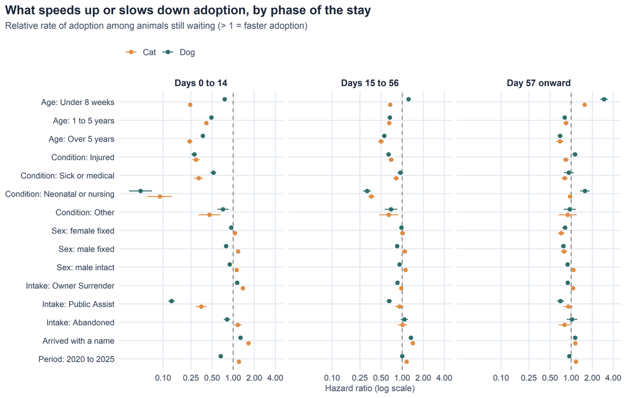

Piecewise hazard ratios for adoption across three stay phases, with 95% confidence intervals. Animals with unrecorded sex (~3.5% of stays) are omitted because almost none were adopted. Source: Austin Animal Center.

- **Age penalties fade—and reverse for juveniles:** Older animals are adopted more slowly across all phases, but the gap narrows over time. In weeks 1–2, animals over 5 are adopted at 24% (cats) to 37% (dogs) of the reference rate; past week 8, both reach ~69%. Conversely, animals arriving under 8 weeks old start slowly (HR = 0.24 for kittens, 0.75 for puppies in days 0–14) but reverse after day 56 once they mature into adoptable juveniles (HR = **2.95** for puppies, **1.55** for kittens).
- **Medical delays are largely temporary:** Injured animals are adopted at ~28%–29% of the normal rate during the first two weeks, improving to ~64%–69% in weeks 3–8. Past day 56, injured dogs actually adopt slightly faster than healthy dogs (HR = **1.13**), while injured cats remain ~16% slower.
- **Neonatal holds resolve after maturation:** Neonatal and nursing animals are rarely adopted in days 0–14 (HR = 0.05–0.09), but among those remaining past day 56, neonatal dogs adopt **1.57x faster** than normal-condition arrivals.
- **Arriving with a name consistently accelerates adoption:** Named animals adopt 1.27x to 1.66x faster in the first eight weeks and ~14% faster afterward—likely serving as a proxy for prior home socialization.
- **Unrecorded sex is an administrative flag:** Roughly 5,800 stays (3.5%) lack recorded sex at intake, and almost none were adopted (1 of 5,028 cats; 24 of 744 dogs). Most were neonates transferred out to rescue partners (85% of cats, 64% of dogs). They are excluded from the adoption plots above so they do not distort scale, though retained in the models.

### What Raises the Risk of Death or Euthanasia?

Because non-live outcomes are concentrated early in a stay, this model is stratified into two phases: **Days 0–14** and **Day 15 onward**.

**Show R code: piecewise Cox models for death or euthanasia**

```r
windows_death <- tibble(window = c("Days 0 to 14", "Day 15 onward"),
                        from   = c(0, 14),
                        to     = c(14, Inf))

hr_death_windows <- bind_rows(
  fit_windows(dogs, "Dog", "Died or euthanized", windows_death),
  fit_windows(cats, "Cat", "Died or euthanized", windows_death)
) |>
  label_terms() |>
  mutate(window = factor(window, levels = windows_death$window))
```

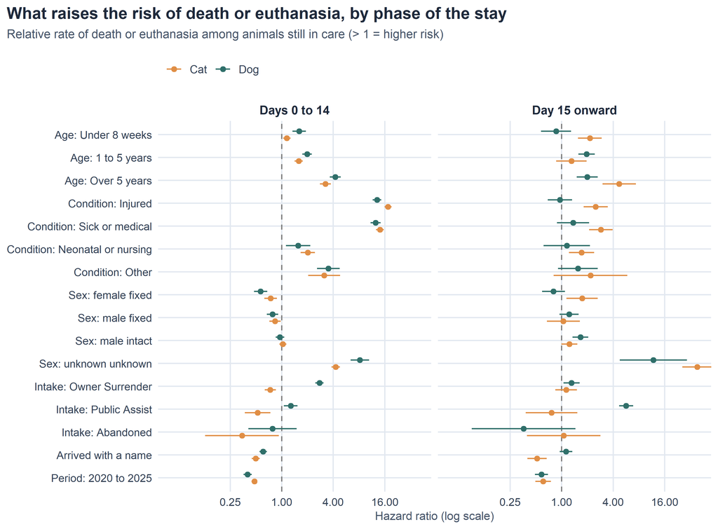

Piecewise hazard ratios for death or euthanasia in two stay phases, with 95% confidence intervals. Source: Austin Animal Center.

- **Arrival condition dominates early mortality:** In the first 14 days, injured and sick dogs die or are euthanized at **13.0x** and **12.5x** the rate of healthy dogs, while injured and sick cats face **17.5x** and **14.0x** the risk of healthy cats. After day 14, surviving injured/sick dogs return to baseline risk (HR = 0.95 and 1.36, confidence intervals spanning 1.0), whereas injured and sick cats remain at elevated risk (HR = **2.50** and **2.87**).
- **Senior animals face sustained vulnerability:** Animals over 5 years old experience 3.2x (cats) to 4.2x (dogs) higher mortality in the first two weeks, and senior cats remaining past day 14 face the highest age-related hazard in the shelter (HR = **4.70**).
- **Intake pathway signals distinct risks:** Owner-surrendered dogs carry **2.76x** the early mortality risk of stray dogs, while public-assist dogs show a sharp late-stay spike after day 14 (HR = **5.67**). Conversely, animals arriving with a name—and animals entering post-2020—experience substantially lower mortality across both species.

## Can High-Risk Animals Be Flagged at Intake?

To test operational utility, I trained a multivariable logistic regression model on pre-2022 intakes (`train`) to predict whether an animal would die or be euthanized within 14 days of arrival, and evaluated its out-of-time performance on unseen 2022–2025 intakes (`test`, $n = 36,140$).

**Show R code: logistic regression risk scoring and AUC evaluation**

```r
# Restrict to stays with at least 14 days of follow-up before cutoff
risk_data <- stays_model |>
  filter(intake_date <= data_cutoff - 14) |>
  mutate(poor = as.integer(outcome_group == "Died or euthanized" & los_days <= 14))

# Temporal train/test split
train <- risk_data |> filter(intake_date <  as_date("2022-01-01"))
test  <- risk_data |> filter(intake_date >= as_date("2022-01-01"))

risk_fit <- glm(poor ~ animal_type * (age_group + condition_model + intake_type) +
                  sex_fixed + has_own_name + era,
                data = train, family = binomial)

test <- test |>
  mutate(risk = predict(risk_fit, newdata = test, type = "response"))

# Rank-based ROC AUC calculation
auc <- function(score, truth) {
  r  <- rank(score)
  n1 <- sum(truth == 1)
  n0 <- sum(truth == 0)
  (sum(r[truth == 1]) - n1 * (n1 + 1) / 2) / (n1 * n0)
}

auc_all <- auc(test$risk, test$poor)
auc_dog <- auc(test$risk[test$animal_type == "Dog"], test$poor[test$animal_type == "Dog"])
auc_cat <- auc(test$risk[test$animal_type == "Cat"], test$poor[test$animal_type == "Cat"])

# Compare model thresholds against a simple condition-based triage rule
score_rule <- function(is_flagged, label) {
  tibble(rule = label,
         flagged = sum(is_flagged),
         share_flagged = mean(is_flagged),
         caught = sum(is_flagged & test$poor == 1),
         share_caught = caught / sum(test$poor),
         precision = caught / flagged)
}

simple_flag <- test$condition_model %in% c("Injured", "Sick or medical")

risk_summary <- bind_rows(
  score_rule(simple_flag, "Baseline rule: flag every injured or sick animal"),
  score_rule(test$risk >= quantile(test$risk, 1 - mean(simple_flag)),
             "Model: flag the same volume of animals (~14.4%)"),
  score_rule(test$risk >= quantile(test$risk, 0.95), "Model: flag top 5% highest risk"),
  score_rule(test$risk >= quantile(test$risk, 0.90), "Model: flag top 10% highest risk"),
  score_rule(test$risk >= quantile(test$risk, 0.80), "Model: flag top 20% highest risk")
)
```

### Triage Rule Comparison (Out-of-Time Test Set: 2022–2025)

| Triage Rule | Animals Flagged | Share of Intakes | 14-Day Deaths/Euth. Caught | Recall (Share Caught) | Precision (Share Right) |
| --- | --- | --- | --- | --- | --- |
| Baseline rule: flag every injured or sick animal | 5,152 | 14.3% | 573 | 64.4% | 11.1% |
| Model: flag the same volume of animals (~14.4%) | 5,200 | 14.4% | 588 | 66.1% | 11.3% |
| Model: flag top 5% highest risk | 1,893 | 5.2% | 351 | 39.4% | 18.5% |
| Model: flag top 10% highest risk | 3,621 | 10.0% | 505 | 56.7% | 13.9% |
| Model: flag top 20% highest risk | 7,413 | 20.5% | 640 | 71.9% | 8.6% |

### Who Falls into the Top 5% Highest-Risk Tier?

| Species | Condition on Arrival | Unrecorded Sex | Animals in Top 5% |
| --- | --- | --- | --- |
| Cat | Injured | No | 812 |
| Cat | Sick or medical | No | 543 |
| Dog | Injured | No | 196 |
| Dog | Sick or medical | No | 178 |
| Cat | Injured | Yes | 77 |
| Cat | Sick or medical | Yes | 55 |
| Dog | Injured | Yes | 17 |
| Dog | Sick or medical | Yes | 8 |
| Dog | Other | Yes | 4 |
| Dog | Other | No | 3 |

### Calibration Across Risk Deciles

| Risk Decile (1 = Lowest, 10 = Highest) | Animals | Average Predicted Risk | Observed 14-Day Mortality |
| --- | --- | --- | --- |
| 1 | 3,614 | 0.2% | 0.2% |
| 2 | 3,614 | 0.4% | 0.2% |
| 3 | 3,614 | 0.4% | 0.7% |
| 4 | 3,614 | 0.5% | 0.9% |
| 5 | 3,614 | 0.8% | 0.7% |
| 6 | 3,614 | 1.0% | 1.1% |
| 7 | 3,614 | 1.1% | 1.3% |
| 8 | 3,614 | 1.5% | 1.8% |
| 9 | 3,614 | 3.6% | 3.7% |
| 10 | 3,614 | 16.4% | 13.9% |

- **Strong discrimination:** On unseen 2022–2025 stays, the model achieves an overall **AUC of 0.83** (**0.80** for dogs and **0.83** for cats), meaning it assigns a higher risk score to an animal that dies or is euthanized within 14 days 83% of the time.
- **Well-calibrated probabilities:** Across deciles 1 through 9, predicted probabilities align within roughly one percentage point of observed outcomes. In the highest-risk decile, the model predicts a **16.4%** risk against an observed **13.9%** rate.
- **Precision-recall trade-off & baseline comparison:** Because early mortality is rare (**2.5%** of the 36,140 test stays), flagging the top 5% captures **39.4%** of poor outcomes with **18.5%** precision (more than 7x the base rate). Notably, a zero-model heuristic—flagging every injured or sick animal (14.3% of arrivals)—captures **64.4%** of poor outcomes at **11.1%** precision, nearly matching the full regression model at the same alert budget (**66.1%** recall, **11.3%** precision).

### Out-of-Schema Validation (May 2025 – November 2026)

To verify that the intake risk model generalizes across the City of Austin’s May 2025 data-schema overhaul, I mapped the 19,547 newer intakes to the legacy feature definitions and evaluated 14-day mortality predictions on live companion-animal arrivals with at least two weeks of follow-up.

**Show R code: post-May 2025 schema mapping and holdout scoring**

```r
# 1. Standardize timestamps and match new-schema intakes to outcomes
intakes_new_clean <- intakes_new |>
  mutate(
    intake_id   = row_number(),
    intake_date = to_date(source_date)
  )

outcomes_new_clean <- outcomes_new |>
  transmute(
    animal_id,
    intake_date    = to_date(intake_date),
    outcome_date   = to_date(outcome_date),
    outcome_status = str_to_lower(outcome_status)
  ) |>
  distinct()

new_cutoff <- max(intakes_new_clean$intake_date, na.rm = TRUE)

stays_new <- intakes_new_clean |>
  left_join(outcomes_new_clean, by = c("animal_id", "intake_date"),
            relationship = "many-to-many") |>
  group_by(intake_id) |>
  slice_min(outcome_date, n = 1, with_ties = FALSE) |>
  ungroup() |>
  mutate(
    still_in_shelter = is.na(outcome_date),
    end_date = coalesce(outcome_date, new_cutoff),
    los_days = as.numeric(end_date - intake_date)
  )

# 2. Map new-schema fields to legacy model predictors
test_2025 <- stays_new |>
  mutate(
    animal_type = case_when(
      type %in% c("Dog", "Puppy") ~ "Dog",
      type %in% c("Cat", "Kitten") ~ "Cat",
      TRUE ~ type
    ),
    cond_lower = str_to_lower(coalesce(intake_health_condition, "normal"))
  ) |>
  filter(
    animal_type %in% c("Dog", "Cat"),
    !str_detect(str_to_lower(coalesce(source_name, "")), "euthanasia|wildlife"),
    cond_lower != "dead",
    !coalesce(outcome_status, "") %in% c("doa"),
    intake_date <= new_cutoff - 14
  ) |>
  mutate(
    dob      = to_date(date_of_birth),
    age_days = as.numeric(intake_date - dob),
    age_days = if_else(age_days < 0, NA_real_, age_days),
    age_group = cut(age_days,
                    breaks = c(-Inf, 56, 365, 365 * 5, Inf),
                    labels = c("Under 8 weeks", "8 weeks to 1 year",
                               "1 to 5 years", "Over 5 years")),
    age_group = relevel(age_group, ref = "8 weeks to 1 year"),

    condition_model = case_when(
      cond_lower == "normal"                        ~ "Normal",
      cond_lower == "injured"                       ~ "Injured",
      str_detect(cond_lower, "sick|med|parvo|neuro|agonal|congenital") ~ "Sick or medical",
      str_detect(cond_lower, "neonat|nurs")         ~ "Neonatal or nursing",
      TRUE                                          ~ "Other"
    ),
    condition_model = factor(condition_model,
                             levels = c("Normal", "Injured", "Sick or medical",
                                        "Neonatal or nursing", "Other")),

    sex_clean = case_when(
      str_to_lower(sex) == "female" ~ "female",
      str_to_lower(sex) == "male"   ~ "male",
      TRUE                          ~ "unknown"
    ),
    fixed_clean = case_when(
      sex_clean == "unknown"                ~ "unknown",
      is_previously_spayed_neutered == TRUE ~ "fixed",
      TRUE                                  ~ "intact"
    ),
    sex_fixed = relevel(factor(paste(sex_clean, fixed_clean)), ref = "female intact"),

    src_lower = str_to_lower(coalesce(source_name, "")),
    intake_type = case_when(
      str_detect(src_lower, "surrender") ~ "Owner Surrender",
      str_detect(src_lower, "public")    ~ "Public Assist",
      str_detect(src_lower, "abandon")   ~ "Abandoned",
      TRUE                               ~ "Stray"
    ),
    intake_type = factor(intake_type,
                         levels = c("Stray", "Owner Surrender",
                                    "Public Assist", "Abandoned")),

    has_own_name = !is.na(name) & !str_detect(name, fixed("*")),
    era = "2020 to 2025",
    poor = as.integer(str_detect(coalesce(outcome_status, ""), "euthan|death") & los_days <= 14)
  ) |>
  filter(!is.na(age_group))

# 3. Score 2025–2026 intakes using the pre-2022 model
test_2025 <- test_2025 |>
  mutate(risk = predict(risk_fit, newdata = test_2025, type = "response"))

auc_2025     <- auc(test_2025$risk, test_2025$poor)
auc_2025_dog <- auc(test_2025$risk[test_2025$animal_type == "Dog"],
                    test_2025$poor[test_2025$animal_type == "Dog"])
auc_2025_cat <- auc(test_2025$risk[test_2025$animal_type == "Cat"],
                    test_2025$poor[test_2025$animal_type == "Cat"])
```

| Triage Rule (2025–2026 Cohort) | Animals Flagged | Share of Intakes | 14-Day Deaths/Euth. Caught | Recall (Share Caught) | Precision (Share Right) |
| --- | --- | --- | --- | --- | --- |
| Baseline rule: flag every injured or sick animal | 834 | 4.9% | 124 | 23.0% | 14.9% |
| Model: flag the same volume of animals | 920 | 5.4% | 146 | 27.1% | 15.9% |
| Model: flag top 5% highest risk | 920 | 5.4% | 146 | 27.1% | 15.9% |
| Model: flag top 10% highest risk | 1,748 | 10.3% | 230 | 42.8% | 13.2% |

Across **16,989 eligible companion-animal stays** in the post-May 2025 dataset (observed 14-day mortality rate: **3.2%**), the pre-2022 model achieves an overall **AUC of 0.79** (**0.79** for dogs and **0.78** for cats). Because the newer intake system leaves `intake_health_condition` unpopulated for most arrivals (tagging only **4.9%** as injured or sick versus **14.3%** in the legacy data), overall recall at the ~5% flag tier shifts to **27.1%** for the model versus **23.0%** for the condition-only heuristic, demonstrating both the model’s continued lift over baseline rules and the operational impact of intake-logging changes.

## Limitations

- **Single-shelter scope.** Findings reflect Austin Animal Center operations and municipal policies and may not generalize directly to shelters with different intake mixes or transfer networks.
- **Approximate intake ages.** Ages are recorded in rounded whole units (`"2 years"`, `"3 weeks"`), making `age_days` an approximation.
- **Potential missing discharge records.** Unmatched intakes within one year of the cutoff date are treated as right-censored stays still in care; a subset may reflect unrecorded exits.
- **Sequential matching assumptions.** Pairing intakes to next outcomes assumes complete record capture; missing intermediate records could misalign multi-visit stays.
- **2025 schema discontinuity.** Because the City of Austin overhauled its animal ID format in May 2025, legacy and modern records cannot be linked across the transition boundary.
- **Pandemic-era structural shift.** COVID-19 sharply reduced 2020 intake volumes and altered species composition through 2024.
- **Outcome grouping assumptions.** Combining `rto-adopt` with owner reclaims and grouping `died` with `euthanasia` simplifies analysis but merges distinct operational events.
- **Intake-only feature horizon.** Post-arrival events—such as medical treatments, behavioral evaluations, foster placement, or promotional campaigns—are unobserved in the intake table.
- **Competing exit pathways.** High reclaim rates for older stray dogs mechanically reduce their cumulative adoption share even when adoption demand is steady.
- **Unrecorded sex records.** Roughly 3.5% of stays lack recorded sex at intake and were almost exclusively transferred as neonates; their adoption hazards cannot be reliably interpreted.
- **Non-proportional hazards & cause-specific interpretation.** Time-varying effects were addressed by stratifying into stay phases; cause-specific hazard ratios reflect rates among animals still waiting rather than cumulative probabilities.
- **Policy-driven euthanasia.** Euthanasia reflects medical severity, behavioral assessment, and shelter capacity decisions rather than purely biological risk.

## Appendix: Data Validation & Model Diagnostics

### Raw File Structure

**Show R code: inspect raw dataset schemas**

```r
glimpse(intakes_old)
```

```
Rows: 173,812
Columns: 14
$ animal_id        <chr> "A521520", "A664235", "A664236", "A664237", "A664233"…
$ name             <chr> "Nina", NA, NA, NA, "Stevie", NA, NA, "*Donnie", "Pip…
$ date_time        <chr> "10/01/2013 07:51:00 AM", "10/01/2013 08:33:00 AM", "…
$ month_year       <chr> "October 2013", "October 2013", "October 2013", "Octo…
$ found_location   <chr> "Norht Ec in Austin (TX)", "Abia in Austin (TX)", "Ab…
$ intake_type      <chr> "Stray", "Stray", "Stray", "Stray", "Stray", "Stray",…
$ intake_condition <chr> "Normal", "Normal", "Normal", "Normal", "Injured", "N…
$ animal_type      <chr> "Dog", "Cat", "Cat", "Cat", "Dog", "Cat", "Dog", "Cat…
$ sex_upon_intake  <chr> "Spayed Female", "Unknown", "Unknown", "Unknown", "In…
$ age_upon_intake  <chr> "7 years", "1 week", "1 week", "1 week", "3 years", "…
$ breed            <chr> "Border Terrier/Border Collie", "Domestic Shorthair M…
$ color            <chr> "White/Tan", "Orange/White", "Orange/White", "Orange/…
$ intake_id        <int> 1, 2, 3, 4, 5, 6, 7, 8, 9, 10, 11, 12, 13, 14, 15, 16…
$ intake_date      <date> 2013-10-01, 2013-10-01, 2013-10-01, 2013-10-01, 2013…
```

**Show R code: inspect raw dataset schemas**

```r
glimpse(outcomes_old)
```

```
Rows: 173,775
Columns: 12
$ animal_id        <chr> "A668305", "A673335", "A675999", "A679066", "A680855"…
$ date_of_birth    <date> 2012-12-01, 2012-02-22, 2013-04-03, 2014-04-16, 2014…
$ name             <chr> NA, NA, NA, NA, NA, NA, NA, NA, NA, NA, NA, NA, "Jenn…
$ date_time        <dttm> 2013-12-02 05:00:00, 2014-02-22 05:00:00, 2014-04-07…
$ month_year       <chr> "12-2013", "02-2014", "04-2014", "05-2014", "06-2014"…
$ outcome_type     <chr> "Transfer", "Euthanasia", "Transfer", NA, "Transfer",…
$ outcome_subtype  <chr> "Partner", "Suffering", "Partner", NA, "Partner", "Pa…
$ animal_type      <chr> "Other", "Other", "Other", "Other", "Bird", "Bird", "…
$ sex_upon_outcome <chr> "Unknown", "Unknown", "Unknown", "Unknown", "Unknown"…
$ age_upon_outcome <chr> "1 year", "2 years", "1 year", "4 weeks", "2 weeks", …
$ breed            <chr> "Turtle Mix", "Raccoon", "Turtle Mix", "Rabbit Sh", "…
$ color            <chr> "Brown/Yellow", "Black/Gray", "Green", "Brown", "Yell…
```

**Show R code: inspect raw dataset schemas**

```r
glimpse(intakes_new)
```

```
Rows: 19,547
Columns: 15
$ id                            <dbl> 40732, 40733, 40731, 40729, 40727, 40728…
$ source_date                   <chr> "2026 Nov 13 05:05:00 PM", "2026 Nov 13 …
$ animal_id                     <dbl> 38025, 38026, 38024, 38022, 38020, 38021…
$ type                          <chr> "Kitten", "Kitten", "Kitten", "Cat", "Do…
$ source_name                   <chr> "Owner Surrender", "Owner Surrender", "O…
$ name                          <chr> "Bronze", "Silver", "Copper", NA, "Wero"…
$ is_previously_spayed_neutered <lgl> FALSE, FALSE, FALSE, FALSE, FALSE, FALSE…
$ sex                           <chr> "Unknown", "Unknown", "Unknown", "Unknow…
$ primary_breed                 <chr> "Domestic Shorthair", "Domestic Shorthai…
$ primary_color                 <chr> "Black", "Black", "Black", "Brown Tabby"…
$ secondary_color               <chr> "White", "White", "White", NA, "White", …
$ intake_health_condition       <chr> NA, NA, NA, NA, NA, NA, NA, "Injured", N…
$ date_of_birth                 <chr> "2026 Aug 13 12:00:00 AM", "2026 Aug 13 …
$ found_address                 <chr> "TX, United States", "TX, United States"…
$ timestamp                     <chr> "2026 Nov 13 06:00:10 PM", "2026 Nov 13 …
```

**Show R code: inspect raw dataset schemas**

```r
glimpse(outcomes_new)
```

```
Rows: 19,903
Columns: 16
$ id                <dbl> 107159, 107156, 107155, 107153, 107152, 107144, 1071…
$ outcome_date      <chr> "2026 Nov 13 07:02:32 PM", "2026 Nov 13 06:26:00 PM"…
$ animal_id         <dbl> 33805, 37905, 37544, 35326, 37604, 32780, 37726, 375…
$ name              <chr> "Max", "Champ", "Tulip", "Tiffany", "Jacob", "Athena…
$ outcome_status    <chr> "Adopted", "Reclaimed", "Adopted", "Adopted", "Adopt…
$ euthanasia_reason <chr> NA, NA, NA, NA, NA, NA, NA, NA, NA, NA, NA, NA, NA, …
$ type              <chr> "Cat", "Dog", "Puppy", "Dog", "Dog", "Cat", "Dog", "…
$ sex               <chr> "Female", "Male", "Female", "Female", "Male", "Femal…
$ spayed_neutered   <chr> "Yes", "Yes", "yes", "Yes", "yes", "Yes", "yes", "Ye…
$ primary_breed     <chr> "Domestic Shorthair", "Boxer", "Great Pyrenees", "Am…
$ primary_color     <chr> "Tortoiseshell", "Red", "Red", "Red", "Black", "Cali…
$ secondary_color   <chr> NA, NA, "White", "White", "White", "White", "White",…
$ date_of_birth     <chr> "2024 Sep 27 12:00:00 AM", "2018 Oct 31 12:00:00 AM"…
$ intake_date       <chr> "2026 Sep 26 04:01:00 PM", "2026 Nov 10 05:15:00 PM"…
$ days_in_shelter   <dbl> 48, 3, 10, 11, 9, 64, 7, 10, 11, 423, 66, 11, 9, 9, …
$ timestamp         <chr> "2026 Nov 13 08:00:12 PM", "2026 Nov 13 07:00:09 PM"…
```

### Date Range & Missingness Checks

All missing date counts should equal `0`, with legacy records spanning October 2013 through May 2025.

**Show R code: verify date ranges and missingness**

```r
sum(is.na(intakes_old$intake_date))
```

```
[1] 0
```

**Show R code: verify date ranges and missingness**

```r
sum(is.na(outcomes_old_clean$outcome_date))
```

```
[1] 0
```

**Show R code: verify date ranges and missingness**

```r
range(intakes_old$intake_date)
```

```
[1] "2013-10-01" "2025-05-04"
```

**Show R code: verify date ranges and missingness**

```r
intakes_old |> count(year = year(intake_date))
```

| year | n |
| --- | --- |
| 2013 | 4182 |
| 2014 | 18656 |
| 2015 | 18712 |
| 2016 | 17675 |
| 2017 | 17563 |
| 2018 | 16979 |
| 2019 | 19727 |
| 2020 | 9587 |
| 2021 | 12043 |
| 2022 | 11896 |
| 2023 | 11227 |
| 2024 | 11817 |
| 2025 | 3748 |

### Outcome Categories & Cutoff Verification

**Show R code: inspect raw outcome labels and file end dates**

```r
outcomes_all |> count(outcome_type, sort = TRUE)
```

| outcome_type | n |
| --- | --- |
| adoption | 84566 |
| transfer | 48680 |
| return to owner | 25687 |
| euthanasia | 10830 |
| died | 1670 |
| rto-adopt | 1239 |
| disposal | 876 |
| missing | 92 |
| — | 46 |
| relocate | 29 |
| stolen | 5 |
| lost | 2 |

**Show R code: inspect raw outcome labels and file end dates**

```r
# Confirm end dates of legacy intake and outcome files
max(intakes_old$intake_date)
```

```
[1] "2025-05-04"
```

**Show R code: inspect raw outcome labels and file end dates**

```r
max(outcomes_all$outcome_date)
```

```
[1] "2025-05-05"
```

### Stay Length Integrity Checks

Negative stay lengths would indicate discharge dates preceding arrival dates and should equal `0`.

**Show R code: verify stay lengths and open records**

```r
stays |>
  count(still_in_shelter)
```

| still_in_shelter | n |
| --- | --- |
| FALSE | 172849 |
| TRUE | 963 |

**Show R code: verify stay lengths and open records**

```r
stays |>
  summarise(n = n(),
            negative_stays = sum(los_days < 0),
            median_los = median(los_days))
```

| n | negative_stays | median_los |
| --- | --- | --- |
| 173812 | 0 | 6 |

**Show R code: verify stay lengths and open records**

```r
stays |>
  arrange(desc(los_days)) |>
  select(animal_id, intake_date, outcome_date, los_days) |>
  head(10)
```

| animal_id | intake_date | outcome_date | los_days |
| --- | --- | --- | --- |
| A683782 | 2014-07-19 | — | 3943 |
| A682781 | 2014-08-13 | — | 3918 |
| A686827 | 2014-09-01 | — | 3899 |
| A636629 | 2014-09-07 | — | 3893 |
| A645513 | 2015-05-18 | — | 3640 |
| A730626 | 2018-02-08 | — | 2643 |
| A642712 | 2016-01-05 | 2021-04-01 | 1913 |
| A764237 | 2017-12-26 | 2022-10-06 | 1745 |
| A722987 | 2016-03-24 | 2020-05-24 | 1522 |
| A702369 | 2015-05-12 | 2019-05-21 | 1470 |

### Unmatched Stays Breakdown

**Show R code: inspect unmatched intakes and long-stay shares**

```r
# 1. Wait duration for unmatched intakes
stays |>
  filter(still_in_shelter) |>
  mutate(wait_group = case_when(
    los_days <= 30  ~ "30 days or less",
    los_days <= 365 ~ "31 to 365 days",
    TRUE            ~ "over a year")) |>
  count(wait_group)
```

| wait_group | n |
| --- | --- |
| 30 days or less | 463 |
| 31 to 365 days | 465 |
| over a year | 35 |

**Show R code: inspect unmatched intakes and long-stay shares**

```r
# 2. Species breakdown of unmatched intakes
stays |>
  filter(still_in_shelter) |>
  count(animal_type, sort = TRUE)
```

| animal_type | n |
| --- | --- |
| Dog | 552 |
| Cat | 394 |
| Other | 15 |
| Bird | 1 |
| Livestock | 1 |

**Show R code: inspect unmatched intakes and long-stay shares**

```r
# 3. Long-stay prevalence among matched records
stays |>
  filter(!still_in_shelter) |>
  summarise(over_90_days = sum(los_days > 90),
            share_over_90 = mean(los_days > 90),
            over_1_year = sum(los_days > 365))
```

| over_90_days | share_over_90 | over_1_year |
| --- | --- | --- |
| 7681 | 0.0444376 | 575 |

### Cleaned Outcome Counts

**Show R code: summarize cleaned outcome groups**

```r
stays_clean |>
  count(outcome_group, sort = TRUE)
```

| outcome_group | n |
| --- | --- |
| Adopted | 82620 |
| Transferred | 47011 |
| Returned to owner | 26753 |
| Died or euthanized | 5952 |
| Still in shelter | 911 |
| Other outcome | 360 |
| Unknown outcome | 46 |

**Show R code: summarize cleaned outcome groups**

```r
stays_clean |>
  count(animal_type, outcome_group) |>
  arrange(animal_type, desc(n))
```

| animal_type | outcome_group | n |
| --- | --- | --- |
| Cat | Adopted | 35432 |
| Cat | Transferred | 26583 |
| Cat | Died or euthanized | 3515 |
| Cat | Returned to owner | 3110 |
| Cat | Still in shelter | 386 |
| Cat | Other outcome | 221 |
| Cat | Unknown outcome | 9 |
| Dog | Adopted | 47188 |
| Dog | Returned to owner | 23643 |
| Dog | Transferred | 20428 |
| Dog | Died or euthanized | 2437 |
| Dog | Still in shelter | 525 |
| Dog | Other outcome | 139 |
| Dog | Unknown outcome | 37 |

### Rationale for Grouping `Died` and `Euthanasia`

Among dogs and cats, 68% of euthanasia cases were recorded under `"Suffering"`, and roughly three-quarters of natural deaths occurred while in shelter or foster care.

**Show R code: inspect death and euthanasia subtypes**

```r
outcomes_old |>
  filter(animal_type %in% c("Dog", "Cat"),
         str_to_lower(outcome_type) %in% c("died", "euthanasia")) |>
  count(outcome_type, outcome_subtype, sort = TRUE)
```

| outcome_type | outcome_subtype | n |
| --- | --- | --- |
| Euthanasia | Suffering | 3236 |
| Died | In Kennel | 758 |
| Euthanasia | Aggressive | 612 |
| Died | In Foster | 361 |
| Euthanasia | Rabies Risk | 217 |
| Euthanasia | At Vet | 215 |
| Euthanasia | Medical | 188 |
| Euthanasia | Behavior | 175 |
| Died | At Vet | 104 |
| Euthanasia | Court/Investigation | 103 |
| Died | Enroute | 59 |
| Died | Emergency | 54 |
| Died | — | 41 |
| Died | In Surgery | 32 |
| Euthanasia | — | 31 |
| Euthanasia | Underage | 1 |

### Intake Feature Distributions

**Show R code: inspect intake feature distributions and mortality rates**

```r
summary(stays_clean$age_days)
```

```
   Min. 1st Qu.  Median    Mean 3rd Qu.    Max.    NA's
    0.0    35.0   365.0   715.8   730.0  8760.0       9
```

**Show R code: inspect intake feature distributions and mortality rates**

```r
stays_clean |> count(sex, fixed)
```

| sex | fixed | n |
| --- | --- | --- |
| female | fixed | 20190 |
| female | intact | 55774 |
| male | fixed | 24054 |
| male | intact | 57860 |
| unknown | unknown | 5775 |

**Show R code: inspect intake feature distributions and mortality rates**

```r
stays_clean |> count(has_own_name)
```

| has_own_name | n |
| --- | --- |
| FALSE | 84623 |
| TRUE | 79030 |

**Show R code: inspect intake feature distributions and mortality rates**

```r
stays_clean |> count(intake_type, sort = TRUE)
```

| intake_type | n |
| --- | --- |
| Stray | 117459 |
| Owner Surrender | 34470 |
| Public Assist | 9864 |
| Abandoned | 1860 |

**Show R code: inspect intake feature distributions and mortality rates**

```r
stays_clean |> count(intake_condition, sort = TRUE)
```

| intake_condition | n |
| --- | --- |
| Normal | 140695 |
| Injured | 9315 |
| Sick | 5942 |
| Nursing | 3773 |
| Neonatal | 1942 |
| Medical | 604 |
| Aged | 481 |
| Other | 338 |
| Pregnant | 170 |
| Feral | 144 |
| Med Attn | 87 |
| Behavior | 81 |
| Unknown | 29 |
| Med Urgent | 20 |
| Neurologic | 11 |
| Parvo | 11 |
| Agonal | 4 |
| Space | 4 |
| Congenital | 1 |
| Panleuk | 1 |

**Show R code: inspect intake feature distributions and mortality rates**

```r
stays_clean |> count(condition_group)
```

| condition_group | n |
| --- | --- |
| Normal | 140695 |
| Injured | 9315 |
| Sick or medical | 6681 |
| Neonatal or nursing | 5715 |
| Aged | 481 |
| Pregnant | 170 |
| Behavior or feral | 225 |
| Other or unknown | 371 |

**Show R code: inspect intake feature distributions and mortality rates**

```r
stays_clean |> count(age_group)
```

| age_group | n |
| --- | --- |
| Under 8 weeks | 41052 |
| 8 weeks to 1 year | 60411 |
| 1 to 5 years | 45021 |
| Over 5 years | 17160 |
| — | 9 |

**Show R code: inspect intake feature distributions and mortality rates**

```r
stays_clean |>
  filter(outcome_group != "Unknown outcome") |>
  group_by(animal_type, condition_group) |>
  summarise(stays = n(),
            share_died_euth = mean(outcome_group == "Died or euthanized"),
            .groups = "drop") |>
  mutate(share_died_euth = scales::percent(share_died_euth, accuracy = 0.1)) |>
  arrange(condition_group, animal_type)
```

| animal_type | condition_group | stays | share_died_euth |
| --- | --- | --- | --- |
| Cat | Normal | 57007 | 2.3% |
| Dog | Normal | 83649 | 1.6% |
| Cat | Injured | 4331 | 28.7% |
| Dog | Injured | 4980 | 12.4% |
| Cat | Sick or medical | 3511 | 21.9% |
| Dog | Sick or medical | 3167 | 10.8% |
| Cat | Neonatal or nursing | 4025 | 4.0% |
| Dog | Neonatal or nursing | 1690 | 3.6% |
| Cat | Aged | 70 | 14.3% |
| Dog | Aged | 411 | 8.8% |
| Cat | Pregnant | 41 | 2.4% |
| Dog | Pregnant | 129 | 0.0% |
| Cat | Behavior or feral | 141 | 5.0% |
| Dog | Behavior or feral | 84 | 13.1% |
| Cat | Other or unknown | 121 | 5.8% |
| Dog | Other or unknown | 250 | 5.2% |

**Show R code: inspect intake feature distributions and mortality rates**

```r
stays_clean |>
  filter(intake_year %in% 2014:2024) |>
  count(intake_year, animal_type) |>
  pivot_wider(names_from = animal_type, values_from = n)
```

| intake_year | Cat | Dog |
| --- | --- | --- |
| 2014 | 6911 | 10485 |
| 2015 | 7471 | 10266 |
| 2016 | 6627 | 9917 |
| 2017 | 6486 | 9935 |
| 2018 | 6020 | 10002 |
| 2019 | 7880 | 10930 |
| 2020 | 3450 | 5419 |
| 2021 | 5112 | 6225 |
| 2022 | 4687 | 6488 |
| 2023 | 5597 | 5075 |
| 2024 | 6047 | 5177 |

### Profile of Stays with Unrecorded Sex

**Show R code: inspect outcomes and ages for unrecorded-sex stays**

```r
stays_model |>
  filter(sex_fixed == "unknown unknown") |>
  count(animal_type, outcome_group, sort = TRUE)
```

| animal_type | outcome_group | n |
| --- | --- | --- |
| Cat | Transferred | 4287 |
| Cat | Died or euthanized | 566 |
| Dog | Transferred | 477 |
| Dog | Returned to owner | 108 |
| Dog | Died or euthanized | 105 |
| Cat | Returned to owner | 86 |
| Cat | Other outcome | 68 |
| Dog | Adopted | 24 |
| Cat | Still in shelter | 20 |
| Dog | Other outcome | 16 |
| Dog | Still in shelter | 14 |
| Cat | Adopted | 1 |

**Show R code: inspect outcomes and ages for unrecorded-sex stays**

```r
stays_model |>
  filter(sex_fixed == "unknown unknown") |>
  count(animal_type, age_group)
```

| animal_type | age_group | n |
| --- | --- | --- |
| Cat | 8 weeks to 1 year | 1095 |
| Cat | Under 8 weeks | 3048 |
| Cat | 1 to 5 years | 826 |
| Cat | Over 5 years | 59 |
| Dog | 8 weeks to 1 year | 95 |
| Dog | Under 8 weeks | 543 |
| Dog | 1 to 5 years | 76 |
| Dog | Over 5 years | 30 |

### Model Checks: Events per Subgroup

**Show R code: verify events per subgroup**

```r
stays_model |>
  group_by(animal_type, condition_model) |>
  summarise(stays = n(),
            adopted = sum(outcome_group == "Adopted"),
            died_euth = sum(outcome_group == "Died or euthanized"),
            .groups = "drop") |>
  knitr::kable(col.names = c("Species", "Condition (model groups)", "Stays",
                             "Adopted", "Died or euthanized"),
               format.args = list(big.mark = ","))
```

| Species | Condition (model groups) | Stays | Adopted | Died or euthanized |
| --- | --- | --- | --- | --- |
| Cat | Normal | 57,006 | 31,811 | 1,313 |
| Cat | Injured | 4,331 | 1,399 | 1,245 |
| Cat | Sick or medical | 3,511 | 1,088 | 770 |
| Cat | Neonatal or nursing | 4,025 | 1,007 | 162 |
| Cat | Other | 373 | 126 | 25 |
| Dog | Normal | 83,643 | 43,387 | 1,354 |
| Dog | Injured | 4,979 | 1,857 | 620 |
| Dog | Sick or medical | 3,167 | 1,032 | 343 |
| Dog | Neonatal or nursing | 1,690 | 623 | 60 |
| Dog | Other | 873 | 287 | 60 |

### Model Checks: Proportional Hazards Diagnostics

Because large sample sizes yield statistically significant $p$-values even for minor deviations, smoothed Schoenfeld residual plots are inspected alongside global $\chi^2$ tests. Sloping curves confirm time-varying effects, motivating the piecewise phase models in the main text.

**Show R code: run Schoenfeld proportional hazards diagnostics**

```r
fit_zph_cat <- coxph(Surv(los_days, outcome_group == "Adopted") ~
                       age_group + condition_model + sex_fixed +
                       intake_type + has_own_name + era, data = cats)
fit_zph_dog <- coxph(Surv(los_days, outcome_group == "Adopted") ~
                       age_group + condition_model + sex_fixed +
                       intake_type + has_own_name + era, data = dogs)

zph_cat <- cox.zph(fit_zph_cat)
zph_dog <- cox.zph(fit_zph_dog)

zph_table <- function(z) {
  z$table |>
    as.data.frame() |>
    tibble::rownames_to_column("term") |>
    mutate(p = format.pval(p, digits = 2, eps = 0.001)) |>
    knitr::kable(digits = 1)
}
```

**Cats: Adoption Model Schoenfeld Test**

| term | chisq | df | p |
| --- | --- | --- | --- |
| age_group | 4128.9 | 3 | <0.001 |
| condition_model | 910.8 | 4 | <0.001 |
| sex_fixed | 1000.1 | 4 | <0.001 |
| intake_type | 1657.9 | 3 | <0.001 |
| has_own_name | 1067.6 | 1 | <0.001 |
| era | 0.0 | 1 | 0.87 |
| GLOBAL | 5441.8 | 16 | <0.001 |

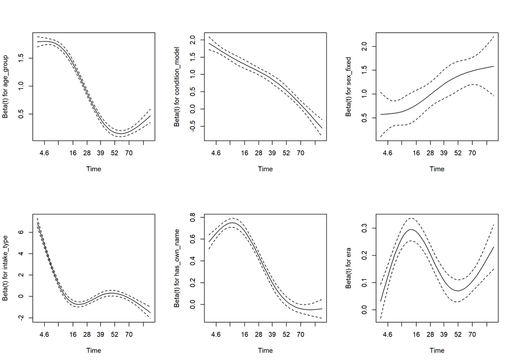

Smoothed Schoenfeld residuals over time for the feline adoption model. Non-flat trajectories indicate time-varying covariate effects.

**Dogs: Adoption Model Schoenfeld Test**

| term | chisq | df | p |
| --- | --- | --- | --- |
| age_group | 759.7 | 3 | <0.001 |
| condition_model | 1627.1 | 4 | <0.001 |
| sex_fixed | 363.0 | 4 | <0.001 |
| intake_type | 2001.6 | 3 | <0.001 |
| has_own_name | 142.9 | 1 | <0.001 |
| era | 551.6 | 1 | <0.001 |
| GLOBAL | 4575.1 | 16 | <0.001 |

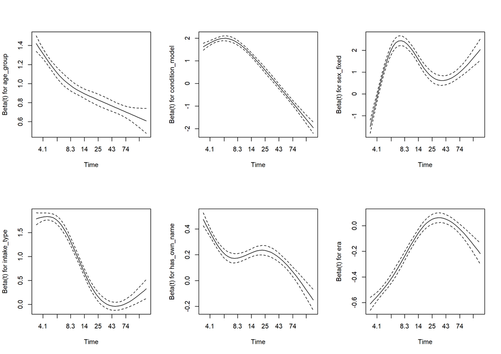

Smoothed Schoenfeld residuals over time for the canine adoption model. Non-flat trajectories indicate time-varying covariate effects.

### Complete Piecewise Hazard Ratio Tables

**Adoption Hazard Ratios (95% CI) by Stay Phase**

| Species | Factor | Days 0 to 14 | Days 15 to 56 | Day 57 onward |
| --- | --- | --- | --- | --- |
| Dog | Age: Under 8 weeks | 0.75 (0.72 to 0.79) | 1.23 (1.17 to 1.30) | 2.95 (2.58 to 3.36) |
| Dog | Age: 1 to 5 years | 0.49 (0.47 to 0.50) | 0.66 (0.64 to 0.69) | 0.81 (0.76 to 0.86) |
| Dog | Age: Over 5 years | 0.37 (0.35 to 0.39) | 0.56 (0.52 to 0.60) | 0.69 (0.64 to 0.75) |
| Dog | Condition: Injured | 0.28 (0.25 to 0.30) | 0.64 (0.59 to 0.69) | 1.13 (1.04 to 1.22) |
| Dog | Condition: Sick or medical | 0.52 (0.47 to 0.57) | 0.94 (0.86 to 1.04) | 0.93 (0.79 to 1.09) |
| Dog | Condition: Neonatal or nursing | 0.05 (0.03 to 0.07) | 0.31 (0.28 to 0.36) | 1.57 (1.35 to 1.83) |
| Dog | Condition: Other | 0.71 (0.59 to 0.86) | 0.69 (0.56 to 0.85) | 0.95 (0.78 to 1.16) |
| Dog | Sex: female fixed | 0.93 (0.89 to 0.97) | 0.97 (0.91 to 1.04) | 0.82 (0.75 to 0.89) |
| Dog | Sex: male fixed | 0.79 (0.75 to 0.82) | 0.85 (0.80 to 0.90) | 0.78 (0.72 to 0.84) |
| Dog | Sex: male intact | 0.89 (0.87 to 0.92) | 0.92 (0.88 to 0.95) | 0.89 (0.83 to 0.94) |
| Dog | Sex: unknown unknown | 0.10 (0.04 to 0.27) | 0.48 (0.35 to 0.66) | 1.74 (1.37 to 2.22) |
| Dog | Intake: Owner Surrender | 1.13 (1.10 to 1.17) | 0.85 (0.82 to 0.89) | 0.89 (0.83 to 0.95) |
| Dog | Intake: Public Assist | 0.13 (0.12 to 0.15) | 0.65 (0.60 to 0.71) | 0.70 (0.63 to 0.79) |
| Dog | Intake: Abandoned | 0.81 (0.73 to 0.91) | 1.07 (0.96 to 1.21) | 1.03 (0.87 to 1.22) |
| Dog | Arrived with a name | 1.27 (1.23 to 1.30) | 1.33 (1.28 to 1.38) | 1.14 (1.08 to 1.20) |
| Dog | Period: 2020 to 2025 | 0.66 (0.64 to 0.68) | 1.00 (0.96 to 1.04) | 0.94 (0.89 to 0.99) |
| Cat | Age: Under 8 weeks | 0.24 (0.23 to 0.26) | 0.67 (0.64 to 0.70) | 1.55 (1.46 to 1.66) |
| Cat | Age: 1 to 5 years | 0.41 (0.39 to 0.44) | 0.65 (0.61 to 0.70) | 0.84 (0.77 to 0.92) |
| Cat | Age: Over 5 years | 0.24 (0.22 to 0.26) | 0.50 (0.45 to 0.55) | 0.69 (0.61 to 0.78) |
| Cat | Condition: Injured | 0.29 (0.26 to 0.33) | 0.69 (0.64 to 0.76) | 0.84 (0.76 to 0.92) |
| Cat | Condition: Sick or medical | 0.32 (0.28 to 0.37) | 0.82 (0.75 to 0.89) | 0.81 (0.73 to 0.90) |
| Cat | Condition: Neonatal or nursing | 0.09 (0.06 to 0.13) | 0.36 (0.33 to 0.40) | 0.97 (0.90 to 1.04) |
| Cat | Condition: Other | 0.46 (0.32 to 0.65) | 0.64 (0.47 to 0.88) | 0.89 (0.66 to 1.20) |
| Cat | Sex: female fixed | 1.06 (0.99 to 1.13) | 1.01 (0.92 to 1.10) | 0.72 (0.65 to 0.81) |
| Cat | Sex: male fixed | 1.17 (1.10 to 1.26) | 1.08 (0.99 to 1.18) | 0.79 (0.71 to 0.88) |
| Cat | Sex: male intact | 1.12 (1.08 to 1.16) | 1.11 (1.07 to 1.15) | 1.08 (1.03 to 1.13) |
| Cat | Sex: unknown unknown | 0.01 (0.00 to 0.04) | 0.00 (0.00 to 0.00) | 0.00 (0.00 to 0.00) |
| Cat | Intake: Owner Surrender | 1.37 (1.31 to 1.43) | 0.97 (0.92 to 1.02) | 1.06 (0.99 to 1.13) |
| Cat | Intake: Public Assist | 0.35 (0.29 to 0.42) | 0.92 (0.80 to 1.06) | 0.91 (0.78 to 1.06) |
| Cat | Intake: Abandoned | 1.16 (1.02 to 1.32) | 1.01 (0.87 to 1.18) | 0.80 (0.66 to 0.98) |
| Cat | Arrived with a name | 1.66 (1.59 to 1.72) | 1.42 (1.36 to 1.47) | 1.14 (1.08 to 1.21) |
| Cat | Period: 2020 to 2025 | 1.20 (1.16 to 1.25) | 1.16 (1.12 to 1.20) | 1.17 (1.12 to 1.22) |

**Death or Euthanasia Hazard Ratios (95% CI) by Stay Phase**

| Species | Factor | Days 0 to 14 | Day 15 onward |
| --- | --- | --- | --- |
| Dog | Age: Under 8 weeks | 1.60 (1.33 to 1.92) | 0.86 (0.57 to 1.29) |
| Dog | Age: 1 to 5 years | 1.97 (1.74 to 2.24) | 1.95 (1.57 to 2.43) |
| Dog | Age: Over 5 years | 4.22 (3.64 to 4.89) | 1.99 (1.50 to 2.64) |
| Dog | Condition: Injured | 12.99 (11.58 to 14.57) | 0.95 (0.69 to 1.33) |
| Dog | Condition: Sick or medical | 12.50 (10.91 to 14.32) | 1.36 (0.88 to 2.09) |
| Dog | Condition: Neonatal or nursing | 1.55 (1.12 to 2.16) | 1.15 (0.61 to 2.15) |
| Dog | Condition: Other | 3.51 (2.58 to 4.76) | 1.55 (0.91 to 2.63) |
| Dog | Sex: female fixed | 0.57 (0.47 to 0.68) | 0.80 (0.59 to 1.09) |
| Dog | Sex: male fixed | 0.78 (0.67 to 0.91) | 1.22 (0.94 to 1.58) |
| Dog | Sex: male intact | 0.95 (0.85 to 1.07) | 1.66 (1.34 to 2.05) |
| Dog | Sex: unknown unknown | 8.18 (6.37 to 10.51) | 11.79 (4.77 to 29.18) |
| Dog | Intake: Owner Surrender | 2.76 (2.47 to 3.08) | 1.30 (1.05 to 1.62) |
| Dog | Intake: Public Assist | 1.27 (1.06 to 1.53) | 5.67 (4.69 to 6.86) |
| Dog | Intake: Abandoned | 0.78 (0.41 to 1.50) | 0.36 (0.09 to 1.45) |
| Dog | Arrived with a name | 0.61 (0.55 to 0.67) | 1.12 (0.95 to 1.33) |
| Dog | Period: 2020 to 2025 | 0.40 (0.36 to 0.44) | 0.58 (0.49 to 0.69) |
| Cat | Age: Under 8 weeks | 1.15 (1.04 to 1.26) | 2.14 (1.55 to 2.94) |
| Cat | Age: 1 to 5 years | 1.58 (1.41 to 1.76) | 1.30 (0.86 to 1.95) |
| Cat | Age: Over 5 years | 3.24 (2.80 to 3.75) | 4.70 (3.00 to 7.36) |
| Cat | Condition: Injured | 17.49 (15.92 to 19.22) | 2.50 (1.80 to 3.46) |
| Cat | Condition: Sick or medical | 14.04 (12.66 to 15.58) | 2.87 (2.09 to 3.94) |
| Cat | Condition: Neonatal or nursing | 2.02 (1.66 to 2.45) | 1.71 (1.22 to 2.39) |
| Cat | Condition: Other | 3.13 (2.03 to 4.81) | 2.17 (0.81 to 5.86) |
| Cat | Sex: female fixed | 0.74 (0.62 to 0.88) | 1.73 (1.14 to 2.64) |
| Cat | Sex: male fixed | 0.83 (0.71 to 0.97) | 1.05 (0.67 to 1.63) |
| Cat | Sex: male intact | 1.03 (0.94 to 1.13) | 1.23 (0.99 to 1.53) |
| Cat | Sex: unknown unknown | 4.27 (3.81 to 4.78) | 38.48 (25.79 to 57.41) |
| Cat | Intake: Owner Surrender | 0.73 (0.63 to 0.85) | 1.13 (0.84 to 1.51) |
| Cat | Intake: Public Assist | 0.52 (0.37 to 0.74) | 0.76 (0.38 to 1.52) |
| Cat | Intake: Abandoned | 0.34 (0.13 to 0.92) | 1.05 (0.39 to 2.84) |
| Cat | Arrived with a name | 0.50 (0.45 to 0.55) | 0.51 (0.40 to 0.67) |
| Cat | Period: 2020 to 2025 | 0.48 (0.44 to 0.52) | 0.61 (0.49 to 0.75) |